# Risk Factor Analysis

## Outcome Variable

**Outcome Variable:** sstunted

## Predictor Variables

**Intervention Variable:** nrooms

**Adjustment Set:**

unadjusted

## Stratifying Variables

The analysis was stratified on these variable(s):

- agecat
- studyid
- country

## Data Summary

| agecat | studyid | country | A | n | nA | nAY0 | nAY1 |
| --- | --- | --- | --- | --- | --- | --- | --- |
| Birth | ki0047075b-MAL-ED | BANGLADESH | 1 | 234 | 144 | 139 | 5 |
| Birth | ki0047075b-MAL-ED | BANGLADESH | 2 | 234 | 50 | 49 | 1 |
| Birth | ki0047075b-MAL-ED | BANGLADESH | 3 | 234 | 28 | 28 | 0 |
| Birth | ki0047075b-MAL-ED | BANGLADESH | 4+ | 234 | 12 | 12 | 0 |
| Birth | ki0047075b-MAL-ED | BRAZIL | 1 | 174 | 3 | 3 | 0 |
| Birth | ki0047075b-MAL-ED | BRAZIL | 2 | 174 | 19 | 19 | 0 |
| Birth | ki0047075b-MAL-ED | BRAZIL | 3 | 174 | 50 | 46 | 4 |
| Birth | ki0047075b-MAL-ED | BRAZIL | 4+ | 174 | 102 | 99 | 3 |
| Birth | ki0047075b-MAL-ED | INDIA | 1 | 191 | 69 | 67 | 2 |
| Birth | ki0047075b-MAL-ED | INDIA | 2 | 191 | 68 | 64 | 4 |
| Birth | ki0047075b-MAL-ED | INDIA | 3 | 191 | 32 | 31 | 1 |
| Birth | ki0047075b-MAL-ED | INDIA | 4+ | 191 | 22 | 22 | 0 |
| Birth | ki0047075b-MAL-ED | NEPAL | 1 | 171 | 36 | 33 | 3 |
| Birth | ki0047075b-MAL-ED | NEPAL | 2 | 171 | 21 | 21 | 0 |
| Birth | ki0047075b-MAL-ED | NEPAL | 3 | 171 | 17 | 17 | 0 |
| Birth | ki0047075b-MAL-ED | NEPAL | 4+ | 171 | 97 | 94 | 3 |
| Birth | ki0047075b-MAL-ED | PERU | 1 | 259 | 17 | 17 | 0 |
| Birth | ki0047075b-MAL-ED | PERU | 2 | 259 | 51 | 50 | 1 |
| Birth | ki0047075b-MAL-ED | PERU | 3 | 259 | 59 | 58 | 1 |
| Birth | ki0047075b-MAL-ED | PERU | 4+ | 259 | 132 | 127 | 5 |
| Birth | ki0047075b-MAL-ED | SOUTH AFRICA | 1 | 218 | 14 | 14 | 0 |
| Birth | ki0047075b-MAL-ED | SOUTH AFRICA | 2 | 218 | 21 | 21 | 0 |
| Birth | ki0047075b-MAL-ED | SOUTH AFRICA | 3 | 218 | 23 | 23 | 0 |
| Birth | ki0047075b-MAL-ED | SOUTH AFRICA | 4+ | 218 | 160 | 159 | 1 |
| Birth | ki0047075b-MAL-ED | TANZANIA, UNITED REPUBLIC OF | 1 | 118 | 6 | 6 | 0 |
| Birth | ki0047075b-MAL-ED | TANZANIA, UNITED REPUBLIC OF | 2 | 118 | 24 | 22 | 2 |
| Birth | ki0047075b-MAL-ED | TANZANIA, UNITED REPUBLIC OF | 3 | 118 | 33 | 31 | 2 |
| Birth | ki0047075b-MAL-ED | TANZANIA, UNITED REPUBLIC OF | 4+ | 118 | 55 | 54 | 1 |
| Birth | ki1000108-CMC-V-BCS-2002 | INDIA | 1 | 90 | 38 | 36 | 2 |
| Birth | ki1000108-CMC-V-BCS-2002 | INDIA | 2 | 90 | 28 | 28 | 0 |

[output cut: 398 more lines]

The following strata were considered:

- agecat: 12 months, studyid: ki0047075b-MAL-ED, country: BANGLADESH
- agecat: 12 months, studyid: ki0047075b-MAL-ED, country: BRAZIL
- agecat: 12 months, studyid: ki0047075b-MAL-ED, country: INDIA
- agecat: 12 months, studyid: ki0047075b-MAL-ED, country: NEPAL
- agecat: 12 months, studyid: ki0047075b-MAL-ED, country: PERU
- agecat: 12 months, studyid: ki0047075b-MAL-ED, country: SOUTH AFRICA
- agecat: 12 months, studyid: ki0047075b-MAL-ED, country: TANZANIA, UNITED REPUBLIC OF
- agecat: 12 months, studyid: ki1000108-CMC-V-BCS-2002, country: INDIA
- agecat: 12 months, studyid: ki1000108-IRC, country: INDIA
- agecat: 12 months, studyid: ki1017093b-PROVIDE, country: BANGLADESH
- agecat: 12 months, studyid: ki1017093c-NIH-Crypto, country: BANGLADESH
- agecat: 12 months, studyid: ki1113344-GMS-Nepal, country: NEPAL
- agecat: 12 months, studyid: ki1114097-CONTENT, country: PERU
- agecat: 12 months, studyid: ki1135781-COHORTS, country: INDIA
- agecat: 12 months, studyid: kiGH5241-JiVitA-3, country: BANGLADESH
- agecat: 12 months, studyid: kiGH5241-JiVitA-4, country: BANGLADESH
- agecat: 18 months, studyid: ki0047075b-MAL-ED, country: BANGLADESH
- agecat: 18 months, studyid: ki0047075b-MAL-ED, country: BRAZIL
- agecat: 18 months, studyid: ki0047075b-MAL-ED, country: INDIA
- agecat: 18 months, studyid: ki0047075b-MAL-ED, country: NEPAL
- agecat: 18 months, studyid: ki0047075b-MAL-ED, country: PERU
- agecat: 18 months, studyid: ki0047075b-MAL-ED, country: SOUTH AFRICA
- agecat: 18 months, studyid: ki0047075b-MAL-ED, country: TANZANIA, UNITED REPUBLIC OF
- agecat: 18 months, studyid: ki1000108-CMC-V-BCS-2002, country: INDIA
- agecat: 18 months, studyid: ki1000108-IRC, country: INDIA
- agecat: 18 months, studyid: ki1017093b-PROVIDE, country: BANGLADESH
- agecat: 18 months, studyid: ki1017093c-NIH-Crypto, country: BANGLADESH
- agecat: 18 months, studyid: ki1113344-GMS-Nepal, country: NEPAL
- agecat: 18 months, studyid: ki1114097-CONTENT, country: PERU
- agecat: 18 months, studyid: kiGH5241-JiVitA-4, country: BANGLADESH
- agecat: 24 months, studyid: ki0047075b-MAL-ED, country: BANGLADESH
- agecat: 24 months, studyid: ki0047075b-MAL-ED, country: BRAZIL
- agecat: 24 months, studyid: ki0047075b-MAL-ED, country: INDIA
- agecat: 24 months, studyid: ki0047075b-MAL-ED, country: NEPAL
- agecat: 24 months, studyid: ki0047075b-MAL-ED, country: PERU
- agecat: 24 months, studyid: ki0047075b-MAL-ED, country: SOUTH AFRICA
- agecat: 24 months, studyid: ki0047075b-MAL-ED, country: TANZANIA, UNITED REPUBLIC OF
- agecat: 24 months, studyid: ki1000108-CMC-V-BCS-2002, country: INDIA
- agecat: 24 months, studyid: ki1000108-IRC, country: INDIA
- agecat: 24 months, studyid: ki1017093b-PROVIDE, country: BANGLADESH
- agecat: 24 months, studyid: ki1017093c-NIH-Crypto, country: BANGLADESH
- agecat: 24 months, studyid: ki1113344-GMS-Nepal, country: NEPAL
- agecat: 24 months, studyid: ki1114097-CONTENT, country: PERU
- agecat: 24 months, studyid: ki1135781-COHORTS, country: INDIA
- agecat: 24 months, studyid: kiGH5241-JiVitA-3, country: BANGLADESH
- agecat: 24 months, studyid: kiGH5241-JiVitA-4, country: BANGLADESH
- agecat: 3 months, studyid: ki0047075b-MAL-ED, country: BANGLADESH
- agecat: 3 months, studyid: ki0047075b-MAL-ED, country: BRAZIL
- agecat: 3 months, studyid: ki0047075b-MAL-ED, country: INDIA
- agecat: 3 months, studyid: ki0047075b-MAL-ED, country: NEPAL
- agecat: 3 months, studyid: ki0047075b-MAL-ED, country: PERU
- agecat: 3 months, studyid: ki0047075b-MAL-ED, country: SOUTH AFRICA
- agecat: 3 months, studyid: ki0047075b-MAL-ED, country: TANZANIA, UNITED REPUBLIC OF
- agecat: 3 months, studyid: ki1000108-CMC-V-BCS-2002, country: INDIA
- agecat: 3 months, studyid: ki1000108-IRC, country: INDIA
- agecat: 3 months, studyid: ki1017093b-PROVIDE, country: BANGLADESH
- agecat: 3 months, studyid: ki1017093c-NIH-Crypto, country: BANGLADESH
- agecat: 3 months, studyid: ki1113344-GMS-Nepal, country: NEPAL
- agecat: 3 months, studyid: ki1114097-CONTENT, country: PERU
- agecat: 3 months, studyid: ki1135781-COHORTS, country: INDIA
- agecat: 3 months, studyid: kiGH5241-JiVitA-3, country: BANGLADESH
- agecat: 3 months, studyid: kiGH5241-JiVitA-4, country: BANGLADESH
- agecat: 6 months, studyid: ki0047075b-MAL-ED, country: BANGLADESH
- agecat: 6 months, studyid: ki0047075b-MAL-ED, country: BRAZIL
- agecat: 6 months, studyid: ki0047075b-MAL-ED, country: INDIA
- agecat: 6 months, studyid: ki0047075b-MAL-ED, country: NEPAL
- agecat: 6 months, studyid: ki0047075b-MAL-ED, country: PERU
- agecat: 6 months, studyid: ki0047075b-MAL-ED, country: SOUTH AFRICA
- agecat: 6 months, studyid: ki0047075b-MAL-ED, country: TANZANIA, UNITED REPUBLIC OF
- agecat: 6 months, studyid: ki1000108-CMC-V-BCS-2002, country: INDIA
- agecat: 6 months, studyid: ki1000108-IRC, country: INDIA
- agecat: 6 months, studyid: ki1017093b-PROVIDE, country: BANGLADESH
- agecat: 6 months, studyid: ki1017093c-NIH-Crypto, country: BANGLADESH
- agecat: 6 months, studyid: ki1113344-GMS-Nepal, country: NEPAL
- agecat: 6 months, studyid: ki1114097-CONTENT, country: PERU
- agecat: 6 months, studyid: ki1135781-COHORTS, country: INDIA
- agecat: 6 months, studyid: kiGH5241-JiVitA-3, country: BANGLADESH
- agecat: 6 months, studyid: kiGH5241-JiVitA-4, country: BANGLADESH
- agecat: 9 months, studyid: ki0047075b-MAL-ED, country: BANGLADESH
- agecat: 9 months, studyid: ki0047075b-MAL-ED, country: BRAZIL
- agecat: 9 months, studyid: ki0047075b-MAL-ED, country: INDIA
- agecat: 9 months, studyid: ki0047075b-MAL-ED, country: NEPAL
- agecat: 9 months, studyid: ki0047075b-MAL-ED, country: PERU
- agecat: 9 months, studyid: ki0047075b-MAL-ED, country: SOUTH AFRICA
- agecat: 9 months, studyid: ki0047075b-MAL-ED, country: TANZANIA, UNITED REPUBLIC OF
- agecat: 9 months, studyid: ki1000108-CMC-V-BCS-2002, country: INDIA
- agecat: 9 months, studyid: ki1000108-IRC, country: INDIA
- agecat: 9 months, studyid: ki1017093b-PROVIDE, country: BANGLADESH
- agecat: 9 months, studyid: ki1017093c-NIH-Crypto, country: BANGLADESH
- agecat: 9 months, studyid: ki1113344-GMS-Nepal, country: NEPAL
- agecat: 9 months, studyid: ki1114097-CONTENT, country: PERU
- agecat: 9 months, studyid: ki1135781-COHORTS, country: INDIA
- agecat: 9 months, studyid: kiGH5241-JiVitA-4, country: BANGLADESH
- agecat: Birth, studyid: ki0047075b-MAL-ED, country: BANGLADESH
- agecat: Birth, studyid: ki0047075b-MAL-ED, country: BRAZIL
- agecat: Birth, studyid: ki0047075b-MAL-ED, country: INDIA
- agecat: Birth, studyid: ki0047075b-MAL-ED, country: NEPAL
- agecat: Birth, studyid: ki0047075b-MAL-ED, country: PERU
- agecat: Birth, studyid: ki0047075b-MAL-ED, country: SOUTH AFRICA
- agecat: Birth, studyid: ki0047075b-MAL-ED, country: TANZANIA, UNITED REPUBLIC OF
- agecat: Birth, studyid: ki1000108-CMC-V-BCS-2002, country: INDIA
- agecat: Birth, studyid: ki1000108-IRC, country: INDIA
- agecat: Birth, studyid: ki1017093c-NIH-Crypto, country: BANGLADESH
- agecat: Birth, studyid: ki1114097-CONTENT, country: PERU
- agecat: Birth, studyid: ki1135781-COHORTS, country: INDIA
- agecat: Birth, studyid: kiGH5241-JiVitA-3, country: BANGLADESH
- agecat: Birth, studyid: kiGH5241-JiVitA-4, country: BANGLADESH

### Dropped Strata

Some strata were dropped due to rare outcomes:

- agecat: Birth, studyid: ki0047075b-MAL-ED, country: BANGLADESH
- agecat: Birth, studyid: ki0047075b-MAL-ED, country: BRAZIL
- agecat: Birth, studyid: ki0047075b-MAL-ED, country: INDIA
- agecat: Birth, studyid: ki0047075b-MAL-ED, country: NEPAL
- agecat: Birth, studyid: ki0047075b-MAL-ED, country: PERU
- agecat: Birth, studyid: ki0047075b-MAL-ED, country: SOUTH AFRICA
- agecat: Birth, studyid: ki0047075b-MAL-ED, country: TANZANIA, UNITED REPUBLIC OF
- agecat: Birth, studyid: ki1000108-CMC-V-BCS-2002, country: INDIA
- agecat: Birth, studyid: ki1000108-IRC, country: INDIA
- agecat: Birth, studyid: ki1017093c-NIH-Crypto, country: BANGLADESH
- agecat: Birth, studyid: ki1114097-CONTENT, country: PERU
- agecat: Birth, studyid: ki1135781-COHORTS, country: INDIA
- agecat: Birth, studyid: kiGH5241-JiVitA-4, country: BANGLADESH
- agecat: 3 months, studyid: ki0047075b-MAL-ED, country: BANGLADESH
- agecat: 3 months, studyid: ki0047075b-MAL-ED, country: BRAZIL
- agecat: 3 months, studyid: ki0047075b-MAL-ED, country: INDIA
- agecat: 3 months, studyid: ki0047075b-MAL-ED, country: NEPAL
- agecat: 3 months, studyid: ki0047075b-MAL-ED, country: PERU
- agecat: 3 months, studyid: ki0047075b-MAL-ED, country: SOUTH AFRICA
- agecat: 3 months, studyid: ki0047075b-MAL-ED, country: TANZANIA, UNITED REPUBLIC OF
- agecat: 3 months, studyid: ki1000108-CMC-V-BCS-2002, country: INDIA
- agecat: 3 months, studyid: ki1000108-IRC, country: INDIA
- agecat: 3 months, studyid: ki1017093b-PROVIDE, country: BANGLADESH
- agecat: 3 months, studyid: ki1017093c-NIH-Crypto, country: BANGLADESH
- agecat: 3 months, studyid: ki1113344-GMS-Nepal, country: NEPAL
- agecat: 3 months, studyid: ki1114097-CONTENT, country: PERU
- agecat: 3 months, studyid: ki1135781-COHORTS, country: INDIA
- agecat: 3 months, studyid: kiGH5241-JiVitA-4, country: BANGLADESH
- agecat: 6 months, studyid: ki0047075b-MAL-ED, country: BANGLADESH
- agecat: 6 months, studyid: ki0047075b-MAL-ED, country: BRAZIL
- agecat: 6 months, studyid: ki0047075b-MAL-ED, country: INDIA
- agecat: 6 months, studyid: ki0047075b-MAL-ED, country: NEPAL
- agecat: 6 months, studyid: ki0047075b-MAL-ED, country: PERU
- agecat: 6 months, studyid: ki0047075b-MAL-ED, country: SOUTH AFRICA
- agecat: 6 months, studyid: ki0047075b-MAL-ED, country: TANZANIA, UNITED REPUBLIC OF
- agecat: 6 months, studyid: ki1000108-CMC-V-BCS-2002, country: INDIA
- agecat: 6 months, studyid: ki1000108-IRC, country: INDIA
- agecat: 6 months, studyid: ki1017093b-PROVIDE, country: BANGLADESH
- agecat: 6 months, studyid: ki1017093c-NIH-Crypto, country: BANGLADESH
- agecat: 6 months, studyid: ki1113344-GMS-Nepal, country: NEPAL
- agecat: 6 months, studyid: ki1114097-CONTENT, country: PERU
- agecat: 6 months, studyid: ki1135781-COHORTS, country: INDIA
- agecat: 6 months, studyid: kiGH5241-JiVitA-4, country: BANGLADESH
- agecat: 9 months, studyid: ki0047075b-MAL-ED, country: BANGLADESH
- agecat: 9 months, studyid: ki0047075b-MAL-ED, country: BRAZIL
- agecat: 9 months, studyid: ki0047075b-MAL-ED, country: INDIA
- agecat: 9 months, studyid: ki0047075b-MAL-ED, country: NEPAL
- agecat: 9 months, studyid: ki0047075b-MAL-ED, country: PERU
- agecat: 9 months, studyid: ki0047075b-MAL-ED, country: SOUTH AFRICA
- agecat: 9 months, studyid: ki0047075b-MAL-ED, country: TANZANIA, UNITED REPUBLIC OF
- agecat: 9 months, studyid: ki1000108-CMC-V-BCS-2002, country: INDIA
- agecat: 9 months, studyid: ki1000108-IRC, country: INDIA
- agecat: 9 months, studyid: ki1017093b-PROVIDE, country: BANGLADESH
- agecat: 9 months, studyid: ki1017093c-NIH-Crypto, country: BANGLADESH
- agecat: 9 months, studyid: ki1113344-GMS-Nepal, country: NEPAL
- agecat: 9 months, studyid: ki1114097-CONTENT, country: PERU
- agecat: 9 months, studyid: ki1135781-COHORTS, country: INDIA
- agecat: 9 months, studyid: kiGH5241-JiVitA-4, country: BANGLADESH
- agecat: 12 months, studyid: ki0047075b-MAL-ED, country: BANGLADESH
- agecat: 12 months, studyid: ki0047075b-MAL-ED, country: BRAZIL
- agecat: 12 months, studyid: ki0047075b-MAL-ED, country: INDIA
- agecat: 12 months, studyid: ki0047075b-MAL-ED, country: NEPAL
- agecat: 12 months, studyid: ki0047075b-MAL-ED, country: PERU
- agecat: 12 months, studyid: ki0047075b-MAL-ED, country: SOUTH AFRICA
- agecat: 12 months, studyid: ki0047075b-MAL-ED, country: TANZANIA, UNITED REPUBLIC OF
- agecat: 12 months, studyid: ki1000108-CMC-V-BCS-2002, country: INDIA
- agecat: 12 months, studyid: ki1000108-IRC, country: INDIA
- agecat: 12 months, studyid: ki1017093b-PROVIDE, country: BANGLADESH
- agecat: 12 months, studyid: ki1017093c-NIH-Crypto, country: BANGLADESH
- agecat: 12 months, studyid: ki1114097-CONTENT, country: PERU
- agecat: 12 months, studyid: ki1135781-COHORTS, country: INDIA
- agecat: 12 months, studyid: kiGH5241-JiVitA-4, country: BANGLADESH
- agecat: 18 months, studyid: ki0047075b-MAL-ED, country: BANGLADESH
- agecat: 18 months, studyid: ki0047075b-MAL-ED, country: BRAZIL
- agecat: 18 months, studyid: ki0047075b-MAL-ED, country: INDIA
- agecat: 18 months, studyid: ki0047075b-MAL-ED, country: NEPAL
- agecat: 18 months, studyid: ki0047075b-MAL-ED, country: PERU
- agecat: 18 months, studyid: ki0047075b-MAL-ED, country: SOUTH AFRICA
- agecat: 18 months, studyid: ki0047075b-MAL-ED, country: TANZANIA, UNITED REPUBLIC OF
- agecat: 18 months, studyid: ki1000108-CMC-V-BCS-2002, country: INDIA
- agecat: 18 months, studyid: ki1000108-IRC, country: INDIA
- agecat: 18 months, studyid: ki1017093b-PROVIDE, country: BANGLADESH
- agecat: 18 months, studyid: ki1017093c-NIH-Crypto, country: BANGLADESH
- agecat: 18 months, studyid: ki1114097-CONTENT, country: PERU
- agecat: 18 months, studyid: kiGH5241-JiVitA-4, country: BANGLADESH
- agecat: 24 months, studyid: ki0047075b-MAL-ED, country: BANGLADESH
- agecat: 24 months, studyid: ki0047075b-MAL-ED, country: BRAZIL
- agecat: 24 months, studyid: ki0047075b-MAL-ED, country: INDIA
- agecat: 24 months, studyid: ki0047075b-MAL-ED, country: NEPAL
- agecat: 24 months, studyid: ki0047075b-MAL-ED, country: PERU
- agecat: 24 months, studyid: ki0047075b-MAL-ED, country: SOUTH AFRICA
- agecat: 24 months, studyid: ki0047075b-MAL-ED, country: TANZANIA, UNITED REPUBLIC OF
- agecat: 24 months, studyid: ki1000108-CMC-V-BCS-2002, country: INDIA
- agecat: 24 months, studyid: ki1000108-IRC, country: INDIA
- agecat: 24 months, studyid: ki1017093b-PROVIDE, country: BANGLADESH
- agecat: 24 months, studyid: ki1017093c-NIH-Crypto, country: BANGLADESH
- agecat: 24 months, studyid: ki1114097-CONTENT, country: PERU
- agecat: 24 months, studyid: ki1135781-COHORTS, country: INDIA
- agecat: 24 months, studyid: kiGH5241-JiVitA-4, country: BANGLADESH

## Methods Detail

We’re interested in the causal parameters $E[Y_a]$ for all values of $a \in \mathcal{A}$. These parameters represent the mean outcome if, possibly contrary to fact, we intervened to set all units to have $A=a$. Under the randomization and positivity assumptions, these are identified by the statistical parameters $\psi_a=E_W[E_{Y|A,W}(Y|A=a,W)]$. In addition, we’re interested in the mean of $Y$, $E[Y]$ under no intervention (the observed mean). We will estimate these parameters by using SuperLearner to fit the relevant likelihood factors – $E_{Y|A,W}(Y|A=a,W)$ and $p(A=a|W)$, and then updating our likelihood fit using a joint TMLE.

For unadjusted analyses ($W=\{\}$), initial likelihoods were estimated using Lrnr_glm to estimate the simple $E(Y|A)$ and Lrnr_mean to estimate $p(A)$. For adjusted analyses, a small library containing Lrnr_glmnet, Lrnr_xgboost, and Lrnr_mean was used.

Having estimated these parameters, we will then use the delta method to estimate relative risks and attributable risks relative to a prespecified baseline level of $A$.

# Results Detail

## Results Plots

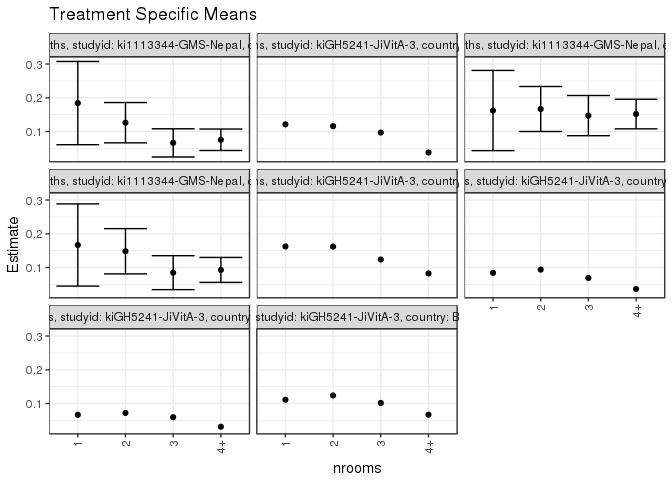

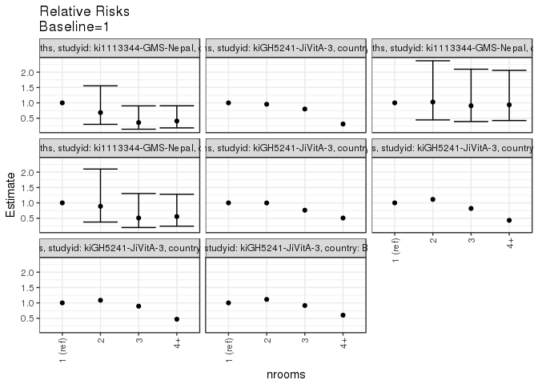

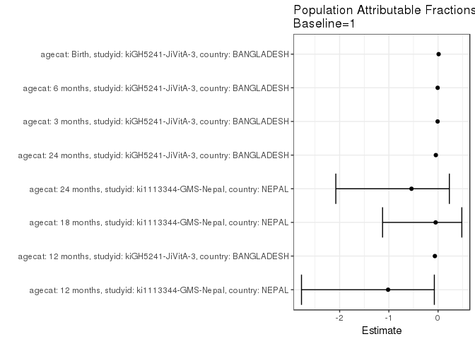

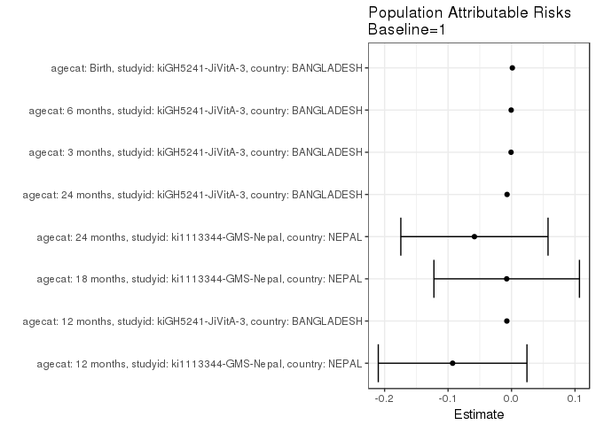

## Results Table

### Parameter: TSM

| agecat | studyid | country | intervention_level | baseline_level | estimate | ci_lower | ci_upper |
| --- | --- | --- | --- | --- | --- | --- | --- |
| Birth | kiGH5241-JiVitA-3 | BANGLADESH | 1 | NA | 0.1113497 | NA | NA |
| Birth | kiGH5241-JiVitA-3 | BANGLADESH | 2 | NA | 0.1239415 | NA | NA |
| Birth | kiGH5241-JiVitA-3 | BANGLADESH | 3 | NA | 0.1017588 | NA | NA |
| Birth | kiGH5241-JiVitA-3 | BANGLADESH | 4+ | NA | 0.0669014 | NA | NA |
| 3 months | kiGH5241-JiVitA-3 | BANGLADESH | 1 | NA | 0.0841474 | NA | NA |
| 3 months | kiGH5241-JiVitA-3 | BANGLADESH | 2 | NA | 0.0937866 | NA | NA |
| 3 months | kiGH5241-JiVitA-3 | BANGLADESH | 3 | NA | 0.0689655 | NA | NA |
| 3 months | kiGH5241-JiVitA-3 | BANGLADESH | 4+ | NA | 0.0363637 | NA | NA |
| 6 months | kiGH5241-JiVitA-3 | BANGLADESH | 1 | NA | 0.0664814 | NA | NA |
| 6 months | kiGH5241-JiVitA-3 | BANGLADESH | 2 | NA | 0.0721607 | NA | NA |
| 6 months | kiGH5241-JiVitA-3 | BANGLADESH | 3 | NA | 0.0593824 | NA | NA |
| 6 months | kiGH5241-JiVitA-3 | BANGLADESH | 4+ | NA | 0.0311615 | NA | NA |
| 12 months | ki1113344-GMS-Nepal | NEPAL | 1 | NA | 0.1842105 | 0.0608455 | 0.3075756 |
| 12 months | ki1113344-GMS-Nepal | NEPAL | 2 | NA | 0.1260504 | 0.0663635 | 0.1857374 |
| 12 months | ki1113344-GMS-Nepal | NEPAL | 3 | NA | 0.0661765 | 0.0243595 | 0.1079934 |
| 12 months | ki1113344-GMS-Nepal | NEPAL | 4+ | NA | 0.0754717 | 0.0436395 | 0.1073039 |
| 12 months | kiGH5241-JiVitA-3 | BANGLADESH | 1 | NA | 0.1211233 | NA | NA |
| 12 months | kiGH5241-JiVitA-3 | BANGLADESH | 2 | NA | 0.1157541 | NA | NA |
| 12 months | kiGH5241-JiVitA-3 | BANGLADESH | 3 | NA | 0.0968622 | NA | NA |
| 12 months | kiGH5241-JiVitA-3 | BANGLADESH | 4+ | NA | 0.0378007 | NA | NA |
| 18 months | ki1113344-GMS-Nepal | NEPAL | 1 | NA | 0.1621622 | 0.0432854 | 0.2810390 |
| 18 months | ki1113344-GMS-Nepal | NEPAL | 2 | NA | 0.1666667 | 0.0999266 | 0.2334067 |
| 18 months | ki1113344-GMS-Nepal | NEPAL | 3 | NA | 0.1470588 | 0.0874818 | 0.2066359 |
| 18 months | ki1113344-GMS-Nepal | NEPAL | 4+ | NA | 0.1517510 | 0.1078470 | 0.1956550 |
| 24 months | ki1113344-GMS-Nepal | NEPAL | 1 | NA | 0.1666667 | 0.0448053 | 0.2885281 |
| 24 months | ki1113344-GMS-Nepal | NEPAL | 2 | NA | 0.1481481 | 0.0810822 | 0.2152141 |
| 24 months | ki1113344-GMS-Nepal | NEPAL | 3 | NA | 0.0847458 | 0.0344452 | 0.1350463 |
| 24 months | ki1113344-GMS-Nepal | NEPAL | 4+ | NA | 0.0928270 | 0.0558449 | 0.1298091 |
| 24 months | kiGH5241-JiVitA-3 | BANGLADESH | 1 | NA | 0.1624139 | NA | NA |
| 24 months | kiGH5241-JiVitA-3 | BANGLADESH | 2 | NA | 0.1619888 | NA | NA |
| 24 months | kiGH5241-JiVitA-3 | BANGLADESH | 3 | NA | 0.1237113 | NA | NA |
| 24 months | kiGH5241-JiVitA-3 | BANGLADESH | 4+ | NA | 0.0824176 | NA | NA |

### Parameter: E(Y)

| agecat | studyid | country | intervention_level | baseline_level | estimate | ci_lower | ci_upper |
| --- | --- | --- | --- | --- | --- | --- | --- |
| Birth | kiGH5241-JiVitA-3 | BANGLADESH | NA | NA | 0.1126297 | NA | NA |
| 3 months | kiGH5241-JiVitA-3 | BANGLADESH | NA | NA | 0.0833944 | NA | NA |
| 6 months | kiGH5241-JiVitA-3 | BANGLADESH | NA | NA | 0.0659288 | NA | NA |
| 12 months | ki1113344-GMS-Nepal | NEPAL | NA | NA | 0.0913978 | 0.0674660 | 0.1153296 |
| 12 months | kiGH5241-JiVitA-3 | BANGLADESH | NA | NA | 0.1137342 | NA | NA |
| 18 months | ki1113344-GMS-Nepal | NEPAL | NA | NA | 0.1545455 | 0.1243087 | 0.1847822 |
| 24 months | ki1113344-GMS-Nepal | NEPAL | NA | NA | 0.1082164 | 0.0809323 | 0.1355005 |
| 24 months | kiGH5241-JiVitA-3 | BANGLADESH | NA | NA | 0.1553896 | NA | NA |

### Parameter: RR

| agecat | studyid | country | intervention_level | baseline_level | estimate | ci_lower | ci_upper |
| --- | --- | --- | --- | --- | --- | --- | --- |
| Birth | kiGH5241-JiVitA-3 | BANGLADESH | 1 | 1 | 1.0000000 | NA | NA |
| Birth | kiGH5241-JiVitA-3 | BANGLADESH | 2 | 1 | 1.1130829 | NA | NA |
| Birth | kiGH5241-JiVitA-3 | BANGLADESH | 3 | 1 | 0.9138664 | NA | NA |
| Birth | kiGH5241-JiVitA-3 | BANGLADESH | 4+ | 1 | 0.6008223 | NA | NA |
| 3 months | kiGH5241-JiVitA-3 | BANGLADESH | 1 | 1 | 1.0000000 | NA | NA |
| 3 months | kiGH5241-JiVitA-3 | BANGLADESH | 2 | 1 | 1.1145523 | NA | NA |
| 3 months | kiGH5241-JiVitA-3 | BANGLADESH | 3 | 1 | 0.8195803 | NA | NA |
| 3 months | kiGH5241-JiVitA-3 | BANGLADESH | 4+ | 1 | 0.4321425 | NA | NA |
| 6 months | kiGH5241-JiVitA-3 | BANGLADESH | 1 | 1 | 1.0000000 | NA | NA |
| 6 months | kiGH5241-JiVitA-3 | BANGLADESH | 2 | 1 | 1.0854272 | NA | NA |
| 6 months | kiGH5241-JiVitA-3 | BANGLADESH | 3 | 1 | 0.8932186 | NA | NA |
| 6 months | kiGH5241-JiVitA-3 | BANGLADESH | 4+ | 1 | 0.4687247 | NA | NA |
| 12 months | ki1113344-GMS-Nepal | NEPAL | 1 | 1 | 1.0000000 | 1.0000000 | 1.0000000 |
| 12 months | ki1113344-GMS-Nepal | NEPAL | 2 | 1 | 0.6842737 | 0.3013188 | 1.5539375 |
| 12 months | ki1113344-GMS-Nepal | NEPAL | 3 | 1 | 0.3592437 | 0.1430573 | 0.9021282 |
| 12 months | ki1113344-GMS-Nepal | NEPAL | 4+ | 1 | 0.4097035 | 0.1856730 | 0.9040464 |
| 12 months | kiGH5241-JiVitA-3 | BANGLADESH | 1 | 1 | 1.0000000 | NA | NA |
| 12 months | kiGH5241-JiVitA-3 | BANGLADESH | 2 | 1 | 0.9556713 | NA | NA |
| 12 months | kiGH5241-JiVitA-3 | BANGLADESH | 3 | 1 | 0.7996991 | NA | NA |
| 12 months | kiGH5241-JiVitA-3 | BANGLADESH | 4+ | 1 | 0.3120844 | NA | NA |
| 18 months | ki1113344-GMS-Nepal | NEPAL | 1 | 1 | 1.0000000 | 1.0000000 | 1.0000000 |
| 18 months | ki1113344-GMS-Nepal | NEPAL | 2 | 1 | 1.0277778 | 0.4457866 | 2.3695804 |
| 18 months | ki1113344-GMS-Nepal | NEPAL | 3 | 1 | 0.9068627 | 0.3924550 | 2.0955271 |
| 18 months | ki1113344-GMS-Nepal | NEPAL | 4+ | 1 | 0.9357977 | 0.4255148 | 2.0580183 |
| 24 months | ki1113344-GMS-Nepal | NEPAL | 1 | 1 | 1.0000000 | 1.0000000 | 1.0000000 |
| 24 months | ki1113344-GMS-Nepal | NEPAL | 2 | 1 | 0.8888889 | 0.3761572 | 2.1005141 |
| 24 months | ki1113344-GMS-Nepal | NEPAL | 3 | 1 | 0.5084746 | 0.1982758 | 1.3039733 |
| 24 months | ki1113344-GMS-Nepal | NEPAL | 4+ | 1 | 0.5569620 | 0.2422169 | 1.2806980 |
| 24 months | kiGH5241-JiVitA-3 | BANGLADESH | 1 | 1 | 1.0000000 | NA | NA |
| 24 months | kiGH5241-JiVitA-3 | BANGLADESH | 2 | 1 | 0.9973822 | NA | NA |
| 24 months | kiGH5241-JiVitA-3 | BANGLADESH | 3 | 1 | 0.7617040 | NA | NA |
| 24 months | kiGH5241-JiVitA-3 | BANGLADESH | 4+ | 1 | 0.5074541 | NA | NA |

### Parameter: PAR

| agecat | studyid | country | intervention_level | baseline_level | estimate | ci_lower | ci_upper |
| --- | --- | --- | --- | --- | --- | --- | --- |
| Birth | kiGH5241-JiVitA-3 | BANGLADESH | 1 | NA | 0.0012800 | NA | NA |
| 3 months | kiGH5241-JiVitA-3 | BANGLADESH | 1 | NA | -0.0007530 | NA | NA |
| 6 months | kiGH5241-JiVitA-3 | BANGLADESH | 1 | NA | -0.0005526 | NA | NA |
| 12 months | ki1113344-GMS-Nepal | NEPAL | 1 | NA | -0.0928127 | -0.2099401 | 0.0243147 |
| 12 months | kiGH5241-JiVitA-3 | BANGLADESH | 1 | NA | -0.0073891 | NA | NA |
| 18 months | ki1113344-GMS-Nepal | NEPAL | 1 | NA | -0.0076167 | -0.1222666 | 0.1070332 |
| 24 months | ki1113344-GMS-Nepal | NEPAL | 1 | NA | -0.0584502 | -0.1744326 | 0.0575321 |
| 24 months | kiGH5241-JiVitA-3 | BANGLADESH | 1 | NA | -0.0070243 | NA | NA |

### Parameter: PAF

| agecat | studyid | country | intervention_level | baseline_level | estimate | ci_lower | ci_upper |
| --- | --- | --- | --- | --- | --- | --- | --- |
| Birth | kiGH5241-JiVitA-3 | BANGLADESH | 1 | NA | 0.0113646 | NA | NA |
| 3 months | kiGH5241-JiVitA-3 | BANGLADESH | 1 | NA | -0.0090295 | NA | NA |
| 6 months | kiGH5241-JiVitA-3 | BANGLADESH | 1 | NA | -0.0083821 | NA | NA |
| 12 months | ki1113344-GMS-Nepal | NEPAL | 1 | NA | -1.0154799 | -2.775385 | -0.0759590 |
| 12 months | kiGH5241-JiVitA-3 | BANGLADESH | 1 | NA | -0.0649683 | NA | NA |
| 18 months | ki1113344-GMS-Nepal | NEPAL | 1 | NA | -0.0492846 | -1.127781 | 0.4825604 |
| 24 months | ki1113344-GMS-Nepal | NEPAL | 1 | NA | -0.5401235 | -2.077847 | 0.2293377 |
| 24 months | kiGH5241-JiVitA-3 | BANGLADESH | 1 | NA | -0.0452044 | NA | NA |